# Profile Plots in Two-Way ANOVA

## Introduction

- Recall that ANOVA allows us to compare the means of three or more groups.
- In one-way ANOVA, we are only considering one factor (grouping variable).
- In this module, we discuss two-way ANOVA, which allows us to consider a second factor (grouping variable).
- In this lecture, we discuss profile plots, a way to visualize treatment group means.

## `R` Setup

```r
library(tidyverse)
library(ssstats)
exam_scores <- read_csv("https://raw.githubusercontent.com/samanthaseals/SDSI/refs/heads/main/files/data/lectures/5-1-exam_scores.csv")
fatigue_scores <- read_csv("https://raw.githubusercontent.com/samanthaseals/SDSI/refs/heads/main/files/data/lectures/5-2-fatigue_scores.csv")
```

## Two-Way ANOVA: Profile Plots

- We can construct profile plots to display treatment group means.
  - *y*-axis: always the average outcome
  - *x*-axis: either factor A or B
  - “lines” on the plot: the factor that was not selected for the *x*-axis
- Note that this is just a graph of the means!
  - It’s valid to construct a profile plot regardless of significance.

## Two-Way ANOVA: Profile Plots (R)

- We will use the `profile_plot()` function from `library(ssstats)` to construct basic profile plots.

```r
dataset_name |> profile_plot(continuous = continuous_variable,
                              xaxis = variable_on_x,
                              lines = variable_for_lines)
```

## Example 1

- Recall the two-way ANOVA results for the `fatigue_scores` data,
- Does the effect of shift on fatigue depend on which unit an officer works in?

```r
fatigue_scores |> anovas(outcome = fatigue_score,
                         A = shift,
                         B = unit)
```

```
Two-way ANOVA (with interaction)

Source       df          SS        MS       F  p-value
─────────────────────────────────────────────────
shift         1    998.2845  998.2845  10.274    0.002
unit          2     51.7080   25.8540   0.266    0.767
shift:unit    2    729.3173  364.6587   3.753    0.025
Residuals   174  16906.4077   97.1633
─────────────────────────────────────────────────


Hypotheses (shift:unit):
H₀: There is no interaction between shift and unit
H₁: There is an interaction between shift and unit
Test statistic: F(2, 174) = 3.753
p-value: 0.025
Conclusion: Reject the null hypothesis (p = 0.025 < α = 0.050)
```

## Example 1

- Let’s remind ourselves what’s “in” the variables:

```r
fatigue_scores |> n_pct(shift, unit)
```

| shift | Desk | K9 | Patrol |
| --- | --- | --- | --- |
| Day | 30 (50.0%) | 30 (50.0%) | 30 (50.0%) |
| Night | 30 (50.0%) | 30 (50.0%) | 30 (50.0%) |

- Neither of the factors has a natural “order”
- Let’s have `unit` on the *x*-axis and define the lines by `shift`.

## Example 1

- Constructing the profile plot,

```r
fatigue_scores |> profile_plot(outcome = fatigue_score,
                              xaxis = unit,
                              lines = shift)
```

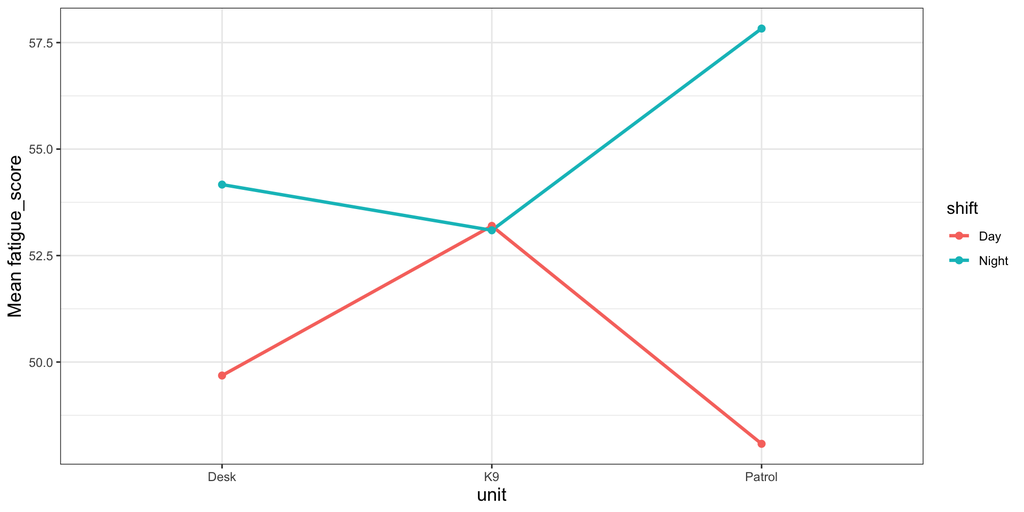

## Example 2

- Recall the two-way ANOVA results for the `exam_scores` data,
- Does the effect of training method depend on experience level?

```r
exam_scores |> anovas(outcome = exam_score,
                      A = training_method,
                      B = experience_level,
                      interaction = TRUE)
```

```
Two-way ANOVA (with interaction)

Source                             df          SS        MS      F  p-value
──────────────────────────────────────────────────────────────────────
training_method                     2   1339.2191  669.6096  7.584  < 0.001
experience_level                    1     88.9014   88.9014  1.007    0.317
training_method:experience_level    2      4.8084    2.4042  0.027    0.973
Residuals                         174  15362.8583   88.2923
──────────────────────────────────────────────────────────────────────


Hypotheses (training_method:experience_level):
H₀: There is no interaction between training_method and experience_level
H₁: There is an interaction between training_method and experience_level
Test statistic: F(2, 174) = 0.027
p-value: 0.973
Conclusion: Fail to reject the null hypothesis (p = 0.973 ≥ α = 0.050)
```

## Example 2

- Recall the two-way ANOVA results for the `exam_scores` data,
- Are there main effects of training method or experience level?

```r
exam_scores |> anovas(outcome = exam_score,
                      A = training_method,
                      B = experience_level,
                      interaction = FALSE)
```

```
Two-way ANOVA (no interaction)

Source             df          SS        MS      F  p-value
──────────────────────────────────────────────────────
training_method     2   1339.2191  669.6096  7.669  < 0.001
experience_level    1     88.9014   88.9014  1.018    0.314
Residuals         176  15367.6668   87.3163
──────────────────────────────────────────────────────


Hypotheses (training_method):
H₀: All means across levels of training_method are equal
H₁: At least one mean across levels of training_method differs
Test statistic: F(2, 176) = 7.669
p-value: < 0.001
Conclusion: Reject the null hypothesis (p = < 0.001 < α = 0.050)

Hypotheses (experience_level):
H₀: All means across levels of experience_level are equal
H₁: At least one mean across levels of experience_level differs
Test statistic: F(1, 176) = 1.018
p-value: 0.314
Conclusion: Fail to reject the null hypothesis (p = 0.314 ≥ α = 0.050)
```

## Example 2

- Let’s remind ourselves what’s “in” the variables:

```r
exam_scores |> n_pct(training_method, experience_level)
```

| training_method | Rookie | Veteran |
| --- | --- | --- |
| Enhanced | 30 (33.3%) | 30 (33.3%) |
| Peer-Led | 30 (33.3%) | 30 (33.3%) |
| Standard | 30 (33.3%) | 30 (33.3%) |

- Neither of the factors has a natural “order”
- Let’s have `training_method` on the *x*-axis and define the lines by `experience_level`.

## Example 2

- Constructing the profile plot,

```r
exam_scores |> profile_plot(outcome = exam_score,
                            xaxis = training_method,
                            lines = experience_level)
```

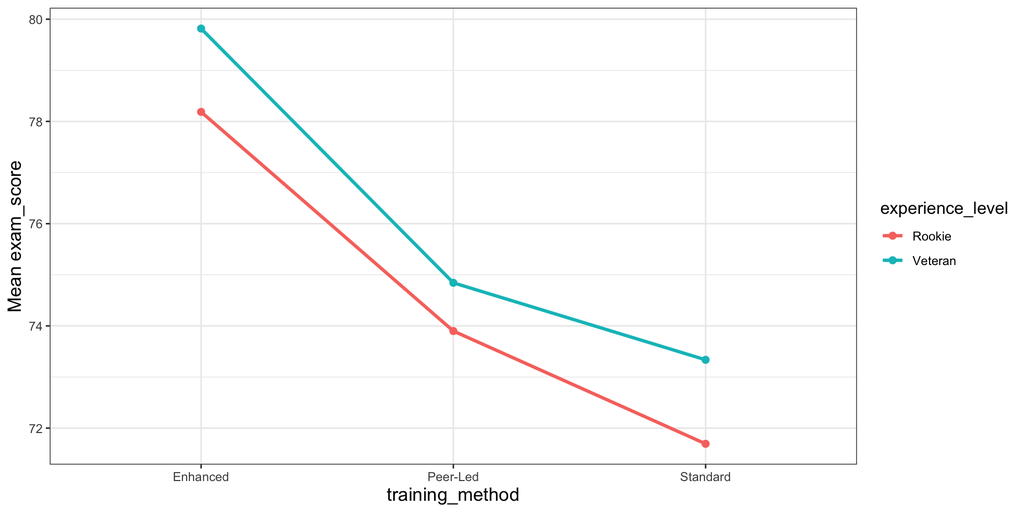

## Wrap Up

- In this lecture, we have covered profile plots in two-way ANOVA.
- This lecture concludes the two-way ANOVA module.
- Next module: categorical analysis.